# JellyCompare

Muriel Dunn

2022-06-28

```r
# tidyverse for cleaner code
library(tidyr)
library(dplyr)
library(purrr)
#apply with progress
library(pbapply)

#plotting
library(ggplot2)

#special libraries
library(ZooScatR)


#pdf stuff
library(kableExtra)
library(knitr)

#exporting results
library(feather)

#define if simulations should be multi-threadded. THis will run the simulations in parallel using with # cores available -1
runParallel = TRUE
if (runParallel == TRUE){
  library(foreach)
  library(doParallel)

  registerDoParallel(parallel::detectCores()-1)
}
#force running a new simulation, even if an RDS file with simualtions is available
force=TRUE
#set working dir
setwd('C:\\Users\\mbd\\phd\\ZooScatStuff\\')
```

## Hydrozoa scattering target strength

Literature on hydrozoa scattering does not report robust measurements of g and h values. Here we compare different TS values from litterature to confirm choices in g and h values.

## Model definition

Let’s start by loading some standard values for the model:

```r
#number of simulations
nsim = 1000
#location of the standard parameter file contained within the package
fname <- paste0(system.file(package="ZooScatR"),"/extdata/configs/config_0.dat")
# read the parameters file
para = ZooScatR::read_para(fname)
#set the soundspeed in the surrounding sea water
misc <- list(cw=1448.01)
#let's set the start and end frequencies
f0=100 #will bepara$simu$var0
f1=450 #will be para$simu$var1
# number of output frequencies
nf=351 #will be para$simu$n
```

A summary of the settings is defined in table 1. The acoustically-dominant species that are considered weakly scatterers are the ones described in the table below. the table also contains all their parameters space settings.

```r
pm = data.frame(species=c('Brierley2001', 'Brierley2004', 'Monger1998'),
  L_dist=c('rnorm', 'rnorm', 'rnorm'),
  L_shape =  c(74, 65, 56), #mm
  L_rate =   c(10, 10, 10),
  L_a_dist = c('rnorm', 'rnorm', 'rnorm'),
  L_a_mean = c(2.8, 2.8, 2.8),
  L_a_sd =   c(0.5, 0.5, 0.5),
  g_dist = 'rnorm',
  g_mean = c(1.007, 1.007, 1.007),
  g_sd = c(0.005, 0.005, 0.005),
  h_dist = 'rnorm',
  h_mean = c(1.007, 1.007, 1.007),
  h_sd = c(0.005, 0.005, 0.005),
  theta_dist = 'rnorm',
  theta_mean = c(90, 90, 90),
  theta_sd =   c(20, 20, 20),
  rho_l =    c( 0, 0, 0),
  taper =    c( 2, 2, 2) #taper =2 L/a>2 prolate spheroid, others selected from ZooScat Ex.
)
```

| species | L_dist | L_shape | L_rate | L_a_dist | L_a_mean | L_a_sd |
| --- | --- | --- | --- | --- | --- | --- |
| Brierley2001 | rnorm | 74 | 10 | rnorm | 2.8 | 0.5 |
| Brierley2004 | rnorm | 65 | 10 | rnorm | 2.8 | 0.5 |
| Monger1998 | rnorm | 56 | 10 | rnorm | 2.8 | 0.5 |

| species | g_dist | g_mean | g_sd | h_dist | h_mean | h_sd |
| --- | --- | --- | --- | --- | --- | --- |
| Brierley2001 | rnorm | 1.007 | 0.005 | rnorm | 1.007 | 0.005 |
| Brierley2004 | rnorm | 1.007 | 0.005 | rnorm | 1.007 | 0.005 |
| Monger1998 | rnorm | 1.007 | 0.005 | rnorm | 1.007 | 0.005 |

| species | theta_dist | theta_mean | theta_sd | rho_l | taper |
| --- | --- | --- | --- | --- | --- |
| Brierley2001 | rnorm | 90 | 20 | 0 | 2 |
| Brierley2004 | rnorm | 90 | 20 | 0 | 2 |
| Monger1998 | rnorm | 90 | 20 | 0 | 2 |

### Define the Model parameters

Now that we have lists of settings we can set those in the parameter files for each species group.

```r
######################################################################
#create a get_para funciton
get_para <- function(pm,spec,fn=-1){

pmsel = pm%>%filter(species==spec)
  if(pmsel$L_dist=='rnorm'){
          L = do.call(pmsel$L_dist,list(nsim,mean=pmsel$L_shape,sd=pmsel$L_rate))
    }else if (pmsel$L_dist=='rlnorm'){
          L = do.call(pmsel$L_dist,list(nsim,meanlog=pmsel$L_shape,sdlog=pmsel$L_rate))
    }else{
          L = do.call(pmsel$L_dist,list(nsim,shape=pmsel$L_shape,rate=pmsel$L_rate))
  }
  cp = data.frame(species=spec,
  L=L,
  La=do.call(pmsel$L_a_dist, list(nsim, pmsel$L_a_mean, pmsel$L_a_sd)),
  g=do.call(pmsel$g_dist,list(nsim, pmsel$g_mean, pmsel$g_sd)),
  h=do.call(pmsel$h_dist,list(nsim, pmsel$h_mean, pmsel$h_sd)),
  taper=pmsel$taper,
  rhol=pmsel$rho_l,
  pf=fn,
  theta=do.call(pmsel$theta_dist,list(nsim, pmsel$theta_mean, pmsel$theta_sd)))
  cdf = gather(cp,'var','value',-species,-taper, -rhol,-pf)
  subtit <- c('L' = "Length~(mm)",
  'La' = "L/a",
  'g' ="Density~contrast~g",
  'h' = 'Sound~speed~contrast~h',
  'theta' = 'Angle~theta~(degree)' )
  p <- ggplot(data=cdf, aes(x=value))+
  geom_density()+
  facet_wrap(.~var, scales='free')+#, labeller =labeller(var= as_labeller(subtit, label_parsed)))+
  theme_classic()+
  ggtitle(paste(spec,'- Material properties - Density plots'))+
  xlab('')+ylab('')

  return(list(cp,p))
}
##################################################################
```

#### Hydromedusae (Aglantha digitale)

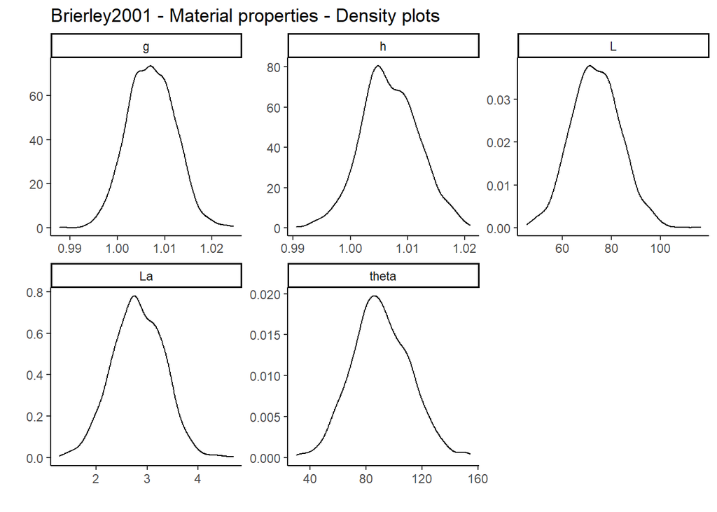

```r
#fn = 'Aglanthadigitale_shape_Moroz2014.sat'
fn = 'Shapes/Hydrozoa_KB3_TT_150122_0026.sat'
B2001out = get_para(pm, 'Brierley2001',fn)
B2001df = B2001out[[1]]
B2001out[[2]]
```

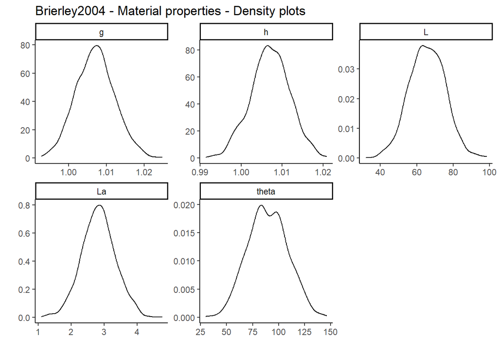

```r
B2004out = get_para(pm, 'Brierley2004',fn)
B2004df = B2004out[[1]]
B2004out[[2]]
```

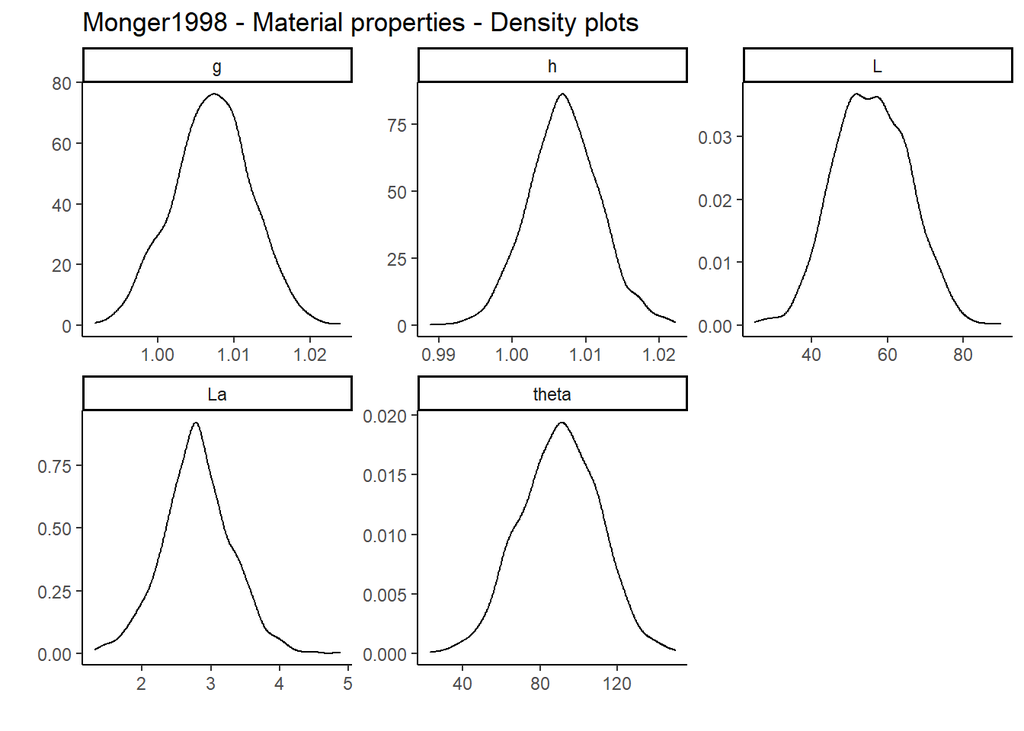

```r
M1998out = get_para(pm, 'Monger1998',fn)
M1998df = M1998out[[1]]
M1998out[[2]]
```

### Run the model

Now we can combine all the settings and prepare to run the simulations:

```r
setdf = do.call('rbind',list(B2001df, B2004df, M1998df))
set_para <- function(i, shape=FALSE, setdf=setdf){
  para = ZooScatR::read_para(fname)
  #set the soundspeed in the surrounding sea water
  #misc <- list(cw=1500)
  #let's set the start and end frequencies
  para$simu$var0=f0
  para$simu$var1=f1
  #number of output frequencies
  para$simu$n=nf
  para$shape$L = setdf$L[i]
  para$shape$L_a = setdf$La[i]
  para$phy$g0 = setdf$g[i]
  para$phy$h0 = setdf$h[i]
  para$shape$order = setdf$taper[i]
  para$shape$rho_L = setdf$rhol[i]
  para$shape$prof_name = setdf$pf[i]
  para$orient$angm = setdf$theta[i]

  if(shape==FALSE){
    res = ZooScatR::bscat(para=para, misc=misc) #Target strength vs Frequency
    tmp=data.frame(TS=res$y,
    freq=seq(f0,f1, length.out = nf),
    L=para$shape$L,
    la=para$shape$L_a,
    g=para$phy$g0,
    h=para$phy$h0,
    orient=para$orient$angm,
    spec=setdf$species[i])
    return(tmp)

  }else{
    p = ZooScatR::buildpos(para)
    p = p$plot
    p = p+coord_equal()
    p = p+ggtitle(setdf$species[i])
    print(p)
    return(p)
  }
}
```

### Model input shapes

First let’s have a look at the selected shapes:

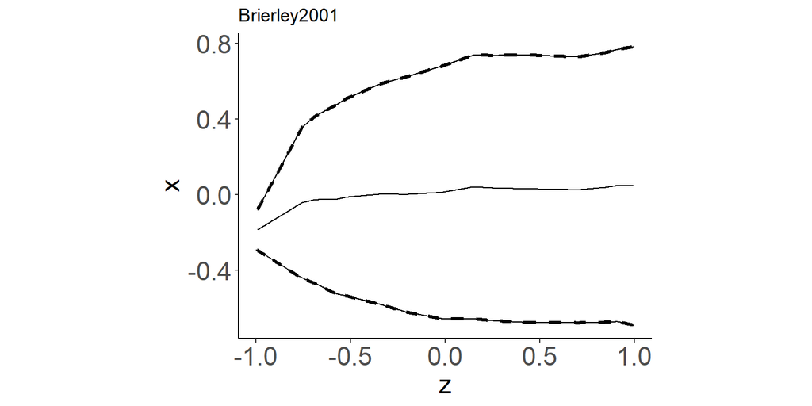

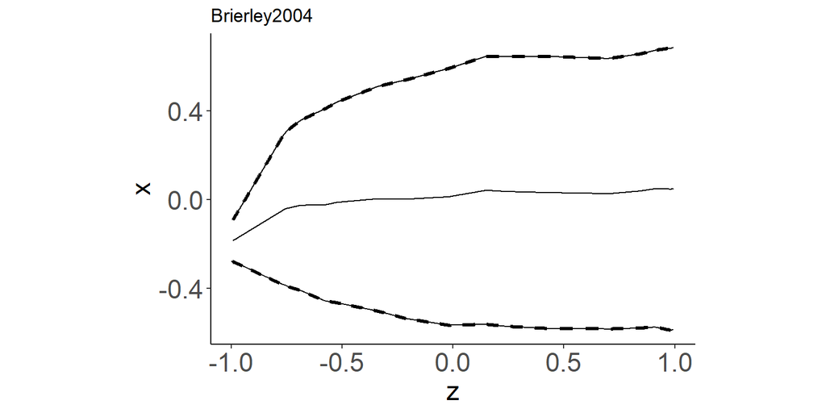

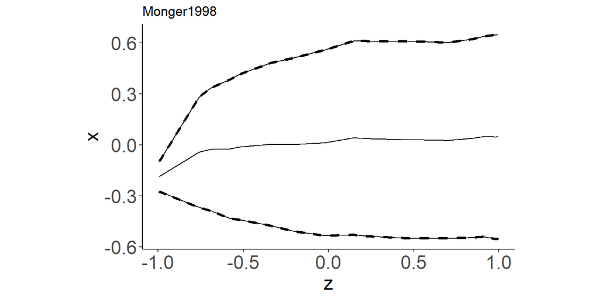

```r
specp = setdf%>%group_by(species)%>%filter(row_number()==1)
for(i in 1:length(specp$species)){set_para(i,shape=TRUE, setdf=specp)}
```

Now we can run the simulations:

```r
if(force ==FALSE & file.exists('sim2.RDS')){
  message(Sys.time(), ': Found simulations...Using old simulaitons...')
  sim = readRDS('sim2.RDS')
}else{
message(Sys.time(),': Running simulations...')
if(runParallel == TRUE){
sim = foreach(i=1:length(setdf$L), .combine=rbind) %dopar% {set_para(i, shape=FALSE,setdf=setdf)}
}else{
sim = do.call('rbind',
pbapply(matrix(1:length(setdf$L)),1,function(i){set_para(i, shape=FALSE,setdf=setdf)})
)
}
message(Sys.time(),': Running simulations completed!')
saveRDS(sim, file='sim2.RDS', compress=TRUE)
}
```

Let’s have a look at the results.

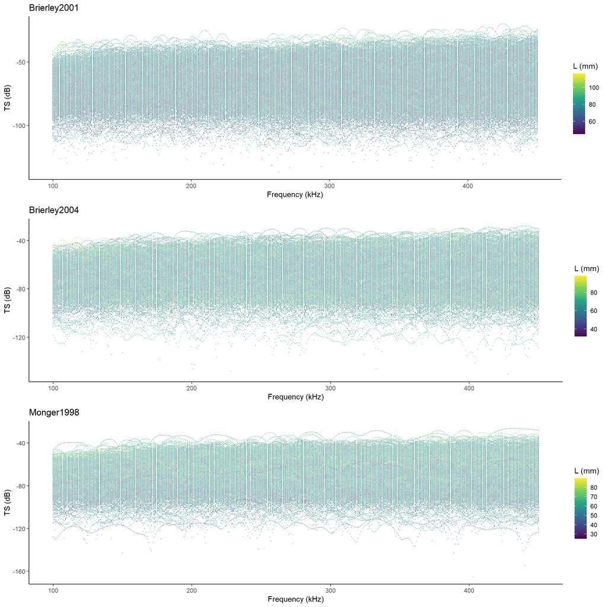

```r
plot_func <- function(sim, name='L (mm)', var='L', y='TS',x='freq', title) {
  ggplot(data = sim, aes_string(x = x, y = y, col = var)) +
    geom_point(size=0.01) +
    scale_colour_viridis_c(name=name)+
    ggtitle(title)+
    xlab('Frequency (kHz)')+
    ylab('TS (dB)')+
    theme_classic()
}
pL <- function(sim,spec){plot_func(sim, name='L (mm)', var='L', y='TS',x='freq', spec)}

sim_tmp <- sim %>%
  group_by(spec) %>%
  nest() %>%
  mutate(plots = map2(data, spec, pL))
pL = gridExtra::grid.arrange(grobs = sim_tmp$plots)
```

To have a look at the overall distribution, we can also look at 2D density plots:

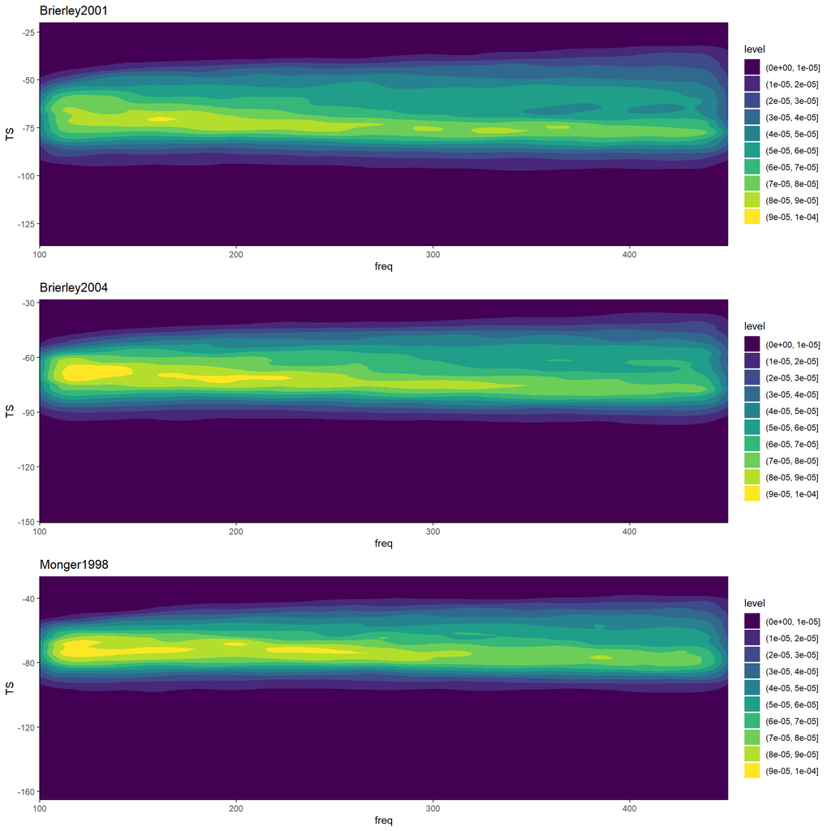

```r
pL <- function(sim, title){

  ggplot(data=sim, aes(x=freq, y=TS))+
    geom_density2d_filled()+
    #facet_wrap(.~spec, scales='free')+
    scale_x_continuous(expand=c(0,0))+
    scale_y_continuous(expand=c(0,0))+
    ggtitle(title)+
    theme_classic()
}


sim_tmp <- sim%>%
  group_by(spec) %>%
  nest() %>%
  mutate(plots = map2(data, spec, pL))
pL = gridExtra::grid.arrange(grobs = sim_tmp$plots)
```

```r
path <- "JellyCompare.feather"
write_feather(sim, path)
```